# Advanced Biological Statistics Week 3

10/09/2018 & 10/11/2018

## Goals for this week

- Finish point estimation
- Tidy data wrangling and Exploratory Data Analysis (EDA)
- Hypothesis testing and Types of errors
- Figures - the good, the bad and the ugly
- Grammar of Graphics (GG) and Creating beautiful graphics using GGPlot2
- Introduction to Linear Models
- Simple linear regression and multiple linear regression (next week)
- Git and GitHub (starting next Tuesday)

## Hypothesis testing, test statistics, p-values

## What is a hypothesis

- A statement of belief about the world
- Need a **critical** test to
  - accept or reject the hypothesis
  - compare the relative merits of different models
- This is where **statistical sampling distributions** come into play

## Hypothesis tests

\(H_0\) : *Null hypothesis* : Ponderosa pine trees are the same height on average as Douglas fir trees

\(H_A\) : *Alternative Hypothesis*: Ponderosa pine trees are not the same height on average as Douglas fir trees

## Hypothesis tests

- What is the probability that we would reject a **true null hypothesis**?
- What is the probability that we would accept a **false null hypothesis**?
- How do we **decide** when to reject a null hypothesis and support an alternative?
- What can we **conclude** if we fail to reject a null hypothesis?
- What **parameter estimates of distributions** are important to test hypotheses?

## Null and alternative hypotheses

### population distributions

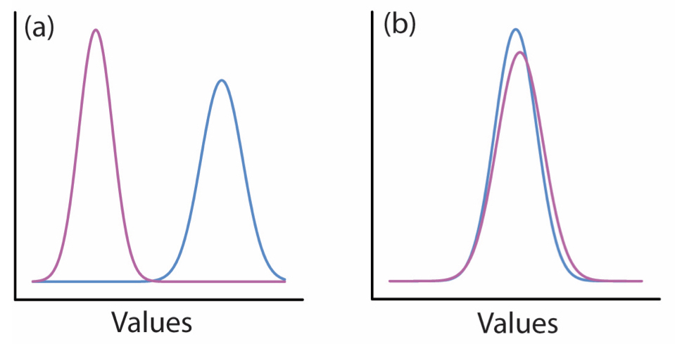

## Null and alternative hypotheses

### population distributions

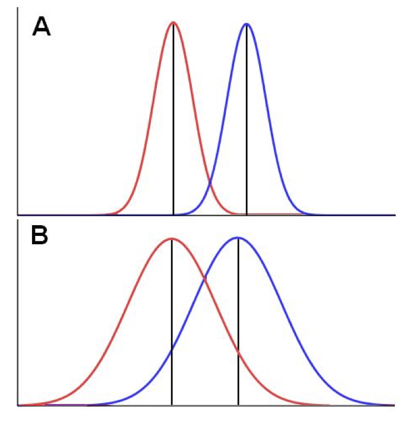

## Statistical sampling distributions

- Statistical tests provide a way to perform **critical tests** of hypotheses
- Just like raw data, statistics are **random variables** and depend on sampling distributions of the underlying data
- The particular **form of the statistical distribution** depends on the test statistic and parameters such as the degrees of freedom that are determined by sample size.

## Statistical sampling distributions

- In many cases we create a **null statistical distribution** that models the distribution of a test statistic under the **null hypothesis**.
- Similar to point estimates, we calculate an **observed test statistic value** for our data
- Then see how probable it was by comparing against **the null distribution**
- The probability of seeing that value or greater is called the **p-value** of the statistic

## Four common statistical distributions

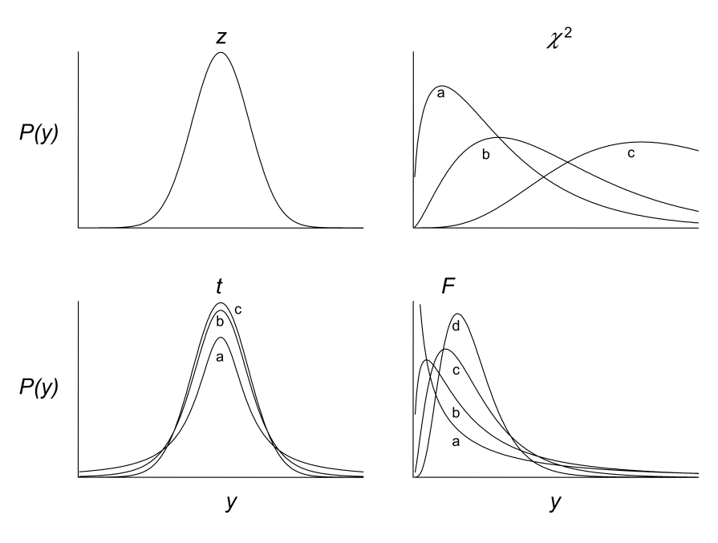

## The t-test and t sampling distribution

\(H_0\) : Null hypothesis : Ponderosa pine trees are the same height on average as Douglas fir trees

\[H_0 : \mu_1 = \mu_2\]

\(H_A\) : Alternative Hypothesis: Ponderosa pine trees are not the same height as Douglas fir trees

\[H_A : \mu_1 \neq \mu_2\]

## The t-test and t sampling distribution

\[\huge t = \frac{(\bar{y}_1-\bar{y}_2)}{s_{\bar{y}_1-\bar{y}_2}} \]

where

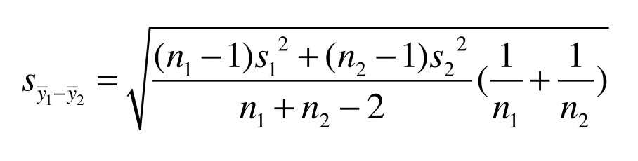

which is the calculation for the standard error of the mean difference

## The t-test and t sampling distribution

### under different degrees of freedom

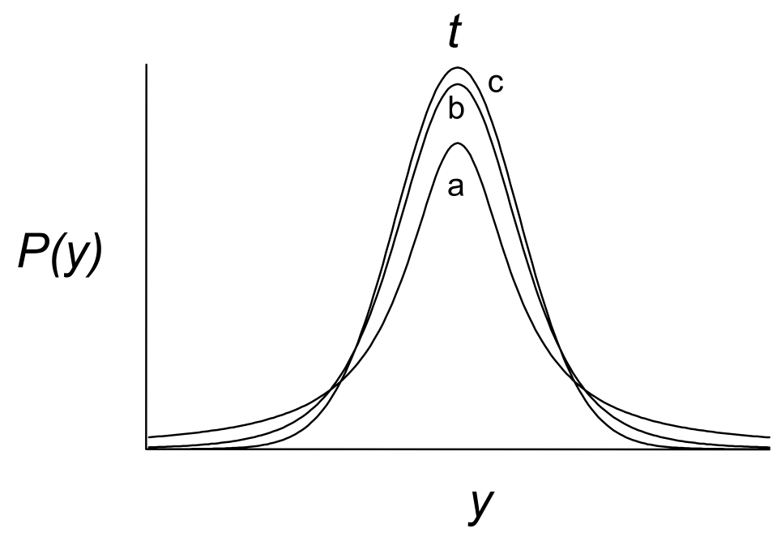

## The t-test and t sampling distribution

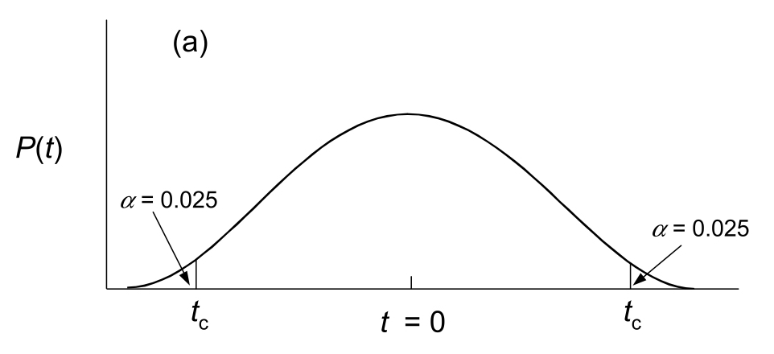

## The t-test and t sampling distribution

### two tailed test

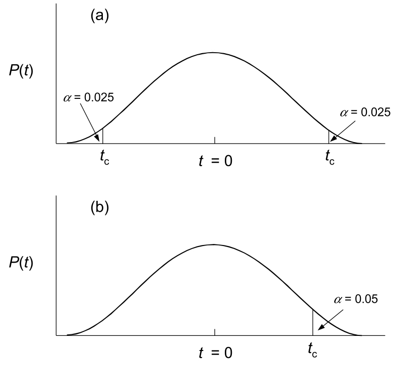

## Assumptions of parameteric t-tests

- The theoretical t-distributions for each degree of freedom were calculated for populations that are:
  - normally distributed
  - have equal variances (if comparing two means)
  - observations are independent (randomly drawn)
- This is an example of a **parametric** test
- What do you do if the there is non-normality?
  - nonparametric tests such as Mann-Whitney-Wilcoxon
  - randomization tests to create a null distribution

## Type 1 and Type 2 errors

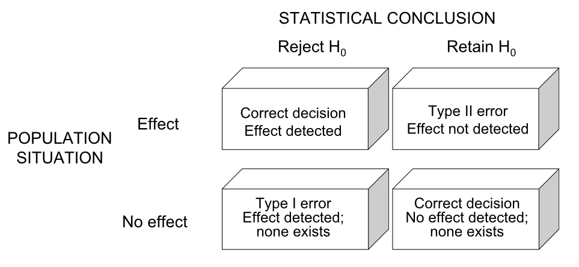

## Components of hypothesis testing

- **p-value** = the long run probability of rejecting a true null hypothesis
- **alpha** = critical value of p-value cutoff for experiments. The Type I error we are willing to tolerate.
- **beta** = cutoff for probability of accepting a false null hypothesis
- **Power** = the probability that a test will reject a false null hypothesis (1 - beta). It depends on effect size, sample size, chosen alpha, and population standard deviation
- **Multiple testing** = performing the same or similar tests multiple times - need to correct

## Null distributions and p-values

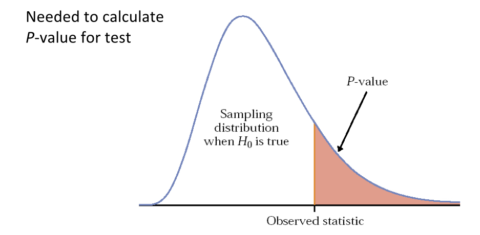

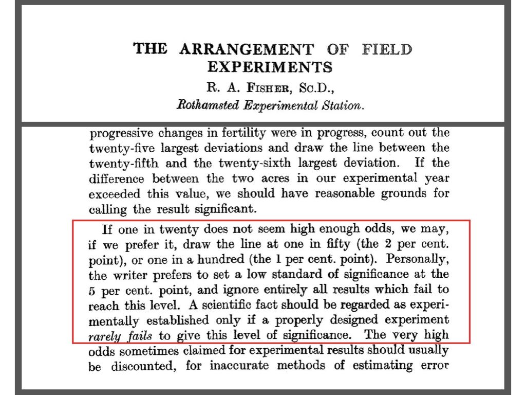

## R INTERLUDE

### Parametric t-test in R

1. Make a dummy data set that contains one continuous and one categorical value (with two levels). Draw individuals of the two different factor levels from normal distributions with slightly different means. Take 100 obsv. per factor level.
2. Now, perform a t-test to see if the two populations are statistically different from one another

```r
boxplot(continuous_variable~cat_variable, dataset name)
t.test(continuous_variable~cat_variable, dataset name)
```

1. Repeat steps 1 and 2 above but use different sample sizes (e.g. 10 , then 100, then 1000, then 10,000 obsv. per factor level)
2. Repeat steps 1 and 2 above but now test between a categorical and continuous variable in the perchlorate data set (or any of your favorite data sets)

## R INTERLUDE

### Parametric t-test in R

- Now, apply the equations for the t-statistic above to your simulated sample to perform the same test, but using a resampling approach
  - hint: go back to your Bootstrapping script
- Use this approach to calculate a distribution of random t statistics assuming the the null hypothesis of no difference is true.
- Now, compare your observed value to your created null distribution.
- What is the probability of that value occurring by chance under the null?
  - This is your p-value! (Assume you’re doing a one-tailed test)
  - hint: Proportion of values in the null distribution equal to or larger than the observed t-value = p-value

## R INTERLUDE

### Permutation t-test in R

- Randomization test example 1
- Data: The number of successful broods of pseudoscorpion females that were mated twice to either a single male (SM) or two different males (DM).
  - SM: `4 0 3 1 2 3 4 2 4 2 0 2 0 1 2 6 0 2 3 3`
  - DM: `2 0 2 6 4 3 4 4 2 7 4 1 6 3 6 4`
- Observed difference in the means between the two
  - \(\bar{Y}_{SM}\) − \(\bar{Y}_{DM}\) = 2.2−3.625 = −1.425

## R INTERLUDE

### Permutation t-test in R

- Steps of the randomization test
- First, create a randomized data set in which the measurements are randomly reassigned (without replacement) to the two groups
  - For example, the following
  - SM: `4 0 7 4 2 2 2 1 4 4 0 3 3 4 6 2 4 6 0 0`
  - DM: `2 2 3 3 2 3 3 4 1 2 1 4 6 6 2 0`
- Second, calculate the test statistic measuring the association between variables
  - difference between group means
  - this is the first bootstrap replicate
- Repeat steps 1 and 2 many times to produce many bootstrap replicates

## R INTERLUDE

### Permutation t-test in R

- Below is the **null distribution** of the test statistic from 10,000 replications
  - This is produced by the randomized assignment of values to each group (SM or DM)
  - Thus this is the distribution we’d expect under the null hypothesis of no difference
- The observed value from the data is –1.425
- The area in red is the tail beyond this observed value and is therefore the **bootstrap p-value**

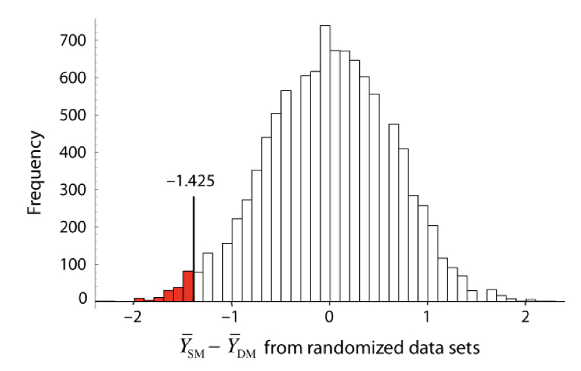

## Data wrangling and exploratory data analysis (EDA)

## Tidyverse family of packages

[figure not shown]

## Tidyverse family of packages

- Hadley Wickham and others have written R packages to modify data
- These packages do many of the same things as base functions in R
- However, they are specifically designed to do them faster and more easily
- Wickham also wrote the package GGPlot2 for elegant graphics creations
- GG stands for ‘Grammar of Graphics’

## Example of a tibble

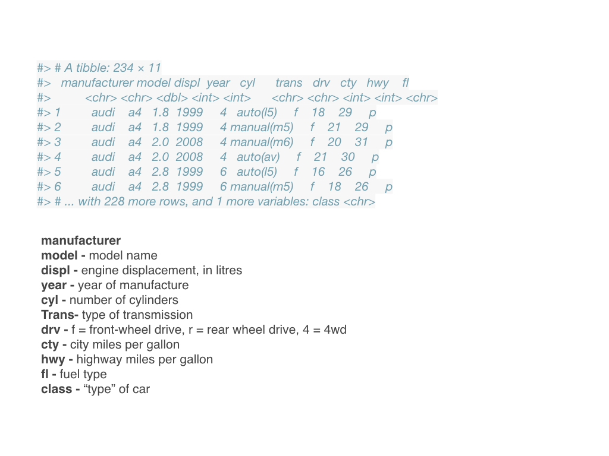

## Example of a tibble

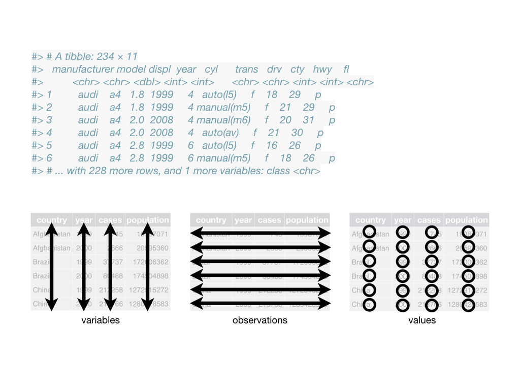

## Types of vectors of data

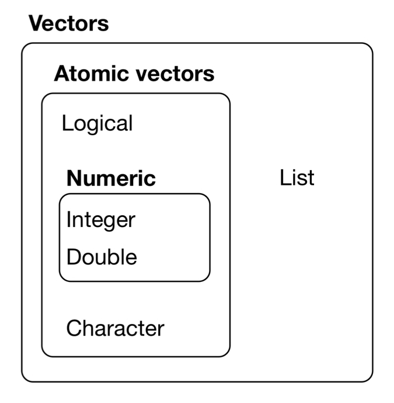

## Types of vectors of data

`int` stands for integers

`db`l stands for doubles, or real numbers

`chr` stands for character vectors, or strings

`dttm` stands for date-times (a date + a time)

`lgl` stands for logical, vectors that contain only TRUE or FALSE

`fctr` stands for factors, which R uses to represent categorical variables with fixed possible values

`date` stands for dates

## Types of vectors of data

- Logical vectors can take only three possible values:
  - `FALSE`
  - `TRUE`
  - `NA` which is ‘not available’.
- Integer and double vectors are known collectively as numeric vectors.
  - In `R` numbers are doubles by default.
- Integers have one special value: NA, while doubles have four:
  - `NA`
  - `NaN` which is ‘not a number’
  - `Inf`
  - `-Inf`

## Types of vectors of data

- R will also implicitly coerce the length of vectors.
  - This is called **vector recycling**
  - The shorter vector is repeated or recycled
  - The shorter vector will be made the same length as the longer vector
- R will expand the shortest vector to the same length as the longest
  - This is so-called **recycling**
  - This is silent except when the length of the longer is not an integer multiple of the length of the shorter
  - When it is not you’ll get an error
- The vectorised functions in tidyverse will throw errors when you recycle anything other than a scalar.
  - If you do want to recycle something other than a scaler
  - You’ll need to do it yourself with `rep()`

## Key functions in `dplyr` for vectors

- Pick observations by their values with `filter()`.
- Reorder the rows with `arrange()`.
- Pick variables by their names with `select()`.
- Create new variables with functions of existing variables with `mutate()`.
- Collapse many values down to a single summary with `summarise()`.

## `filter()`, `arrange()` & `select()`

```r
filter(flights, month == 11 | month == 12)
```

```r
arrange(flights, year, month, day)
```

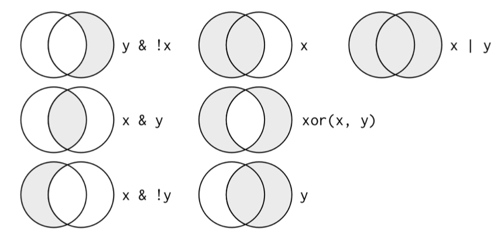

```r
select(flights, year, month, day)
```

## `mutate()` & `transmutate()`

This function will add a new variable that is a function of other variable(s)

```r
mutate(flights_sml,
  gain = arr_delay - dep_delay,
  hours = air_time / 60,
  gain_per_hour = gain / hours
)
```

This function will eplace the old variable with the new variable

```r
transmute(flights,
  gain = arr_delay - dep_delay,
  hours = air_time / 60,
  gain_per_hour = gain / hours
)
```

## `group_by( )` & `summarize( )`

This first function allows you to aggregate data by values of categorical variables

```r
by_day <- group_by(flights, year, month, day)
```

Once you have done this aggregation, you can then calculate values (in this case the mean) of other variables split by the new aggregated levels of the categorical variable

```r
summarise(by_day, delay = mean(dep_delay, na.rm = TRUE))
```

- Note - you can get a lot of missing values!
- That’s because aggregation functions obey the usual rule of missing values:
  - if there’s any missing value in the input, the output will be a missing value.
  - fortunately, all aggregation functions have an na.rm argument which removes the missing values prior to computation

## R INTERLUDE

### Playing with `Tidyverse` functions

- Examine my R script `TidyVerse.R’`
- Step 1 - Read in the GacuRNAseq_Subset.csv dataset
- Step 2 - Make the dataset into a tibble
- Step 3 - Select all of the categorical variables and only 4 of the gene count variables and put them into a new variable
- Step 4 - Mutate each of the 4 gene expression values by performing a square root transformation making a new variable for each of the original (keep all 8 in the dataset).
- Step 5 - Summarize the mean and standard deviation for each of the gene count variables grouped by the ‘sex’ and ‘population’ and ‘treatment’ categorical variables
- Step 6 - Create a histogram for one of the original gene expression variables, and one of the derived variables
- Step 7 - Create a box plot for one of the original gene expression variables, and one of the derived variables, split by treatment
- Step 8 - Write the final data table to a .csv file and one of the figures to a .pdf file